# Assignment 2

Yap Ming Yan (68103)

Muhammad Nasiruddin bin Taha (64958)

26 July, 2022

```r
#import data
data = read_xlsx("C:/Users/User/Desktop/Year 4 Sem 2/Statistical Data Analysis/Assign2data.xlsx")
```

a.Select a random sample consisting of 90% of the data provided (refer to Table 1). Attach your random sample as reference.

```r
random_sample_data = data[sample(nrow(data), 108), ]
X = random_sample_data$Xi1
Y = random_sample_data$Yi
random_sample_data %>% print(n = Inf)
```

```
## # A tibble: 108 × 5
##         i    Yi   Xi1   Xi2   Xi3
##     <dbl> <dbl> <dbl> <dbl> <dbl>
##   1    24  3.92    27   128    95
##   2   109  3.79    28   129    99
##   3   101  1.84    25    95    72
##   4    92  2.18    27    98    59
##   5    53  2.65    30   112    99
##   6   100  2.31    18   104    61
##   7   106  3.72    35   125    99
##   8    45  3.38    26   115    81
##   9    17  3.52    25   119    63
##  10    86  2.92    27   111    83
##  11    68  3.71    32   126    41
##  12    73  2.48    18    99    15
```

[output cut: 96 more lines]

b.Obtain the least squares estimates of $\beta_{0}$ and $\beta_{1}$, and state the estimated regression function.

```r
Xbar = mean(X)
Ybar = mean(Y)

b1 = sum((X - Xbar)*(Y - Ybar)) / sum((X-Xbar)^2)
b1
```

```
## [1] 0.04016581
```

```r
b0 = Ybar - b1*Xbar
b0
```

```
## [1] 2.061588
```

```r
Yhat = b0 + b1*X
```

$\beta_{0} =$ 2.062  
$\beta_{1} =$ 0.04017  
The estimated regression function is $\hat{Y}$ = 2.062 + 0.04017X

c.Plot the estimated regression function and the data. Does the estimated regression function appear to fit the data well?

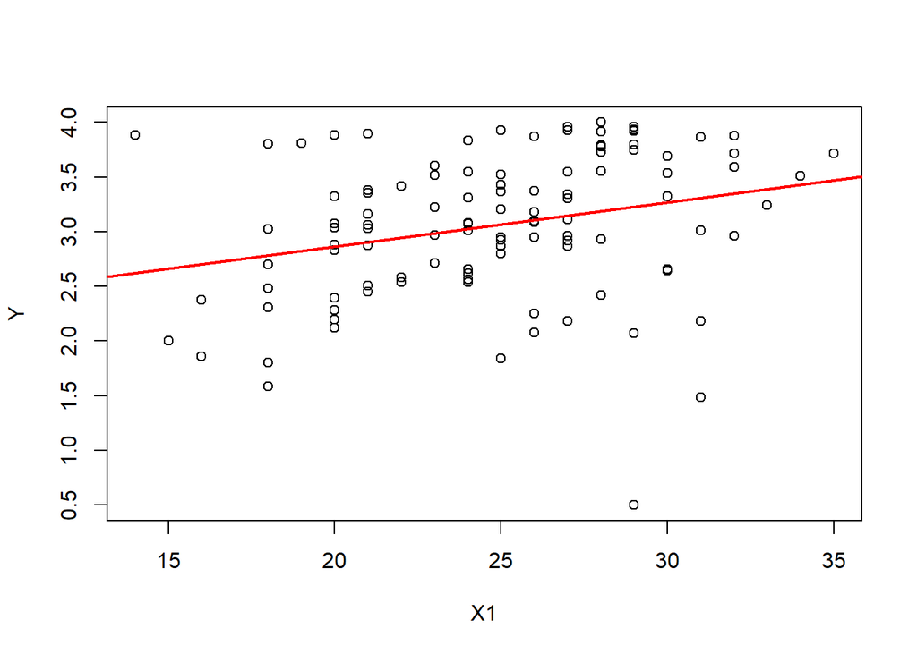

```r
my_lr_model = lm(Y ~ X, random_sample_data) # linear regression function

# plot data observations
plot(Y~X, data = random_sample_data,
     xlab = "X1",
     ylab = "Y")

abline(my_lr_model, lwd = 2, col = "red") # plot regression line
```

d.Obtain a point estimate of the mean freshman GPA for students with ACT test score $X_{1}$ = 30.

```r
Yhat_30 = b0 + b1 * (30)
Yhat_30
```

```
## [1] 3.266562
```

The point estimate of the mean freshman GPA for students with ACT test score $X_{1}$ = 30 is 3.267

e.What is the point estimate of the change in the mean response when the entrance test score increases by one point?  
$\beta_{1}$ is the slope of the regression line. The slope captures the change in the mean response when X increases by one score. Thus, with every increase in entrance test score by one point, the mean freshman GPA for students increases by 0.04017.

f.Obtain a 99% confidence interval for $\beta_{1}$. Interpret your confidence interval. Does it include zero? Why might the director of admissions be interested in whether the confidence interval includes zero?

```r
# Obtain SSE and MSE
n = length(X)
e = Y - Yhat
SSE = sum(e^2)
MSE = SSE / (n - 2)

# Obtain 99% confidence intervals for  beta1
df = n - 2
std_b1 = sqrt(MSE / sum((X - Xbar)^2))
std_b1
```

```
## [1] 0.01389723
```

```r
alpha_half2 = (1 - .99) / 2
alpha_half2
```

```
## [1] 0.005
```

```r
t = qt(1 - alpha_half2, df) # function for t distribution
t
```

```
## [1] 2.623008
```

```r
# confidence interval for b1
lower_b1 = b1 - t*std_b1
lower_b1
```

```
## [1] 0.003713268
```

```r
upper_b1 = b1 + t*std_b1
upper_b1
```

```
## [1] 0.07661835
```

###Verify with built-in function

```r
confint(my_lr_model, level = .99) # function to obtain confidence interval
```

```
##                   0.5 %     99.5 %
## (Intercept) 1.144185177 2.97898997
## X           0.003713268 0.07661835
```

The 99% confidence interval for $\beta_{1}$ is given by:  
$b_{1} \pm t(1 - \frac{\alpha}{2}; n-2)s(b_{1})$

= 0.04017 $\pm$ t(1 - 0.005; 106) $s(b_{1})$  
= 0.04017 $\pm$ 2.623 $s(b_{1})$ = 0.04017 $\pm$ (2.623)(0.0139)

where  
$s^2(b_{1}) = \frac{MSE}{\sum(X - \overline{X})} =$ 1.931^{-4}  
$s(b_{1}) =$ 0.0139

Hence, the 99% confidence interval for $\beta_{1}$ is:  
0.04017 - (2.623)(0.0139) $\leq \beta_{1} \leq$ 0.04017 + (2.623)(0.0139)  
0.00371 $\leq \beta_{1} \leq$ 0.0766

g.Test, using the test statistic t*, whether or not a linear association exists between student’s ACT score (X1) and GPA at the end of the freshman year (Y). Use a level of significance of .01. State the alternatives, decision rule, and conclusion.

```r
test_statistic_t = b1 / std_b1
test_statistic_t
```

```
## [1] 2.890203
```

```r
if(test_statistic_t <= t){
  print("conclude H0")
}else{
  print("conclude Ha")
}
```

```
## [1] "conclude Ha"
```

$H_{0}: \beta_{1} = 0$,  
$H_{a}: \beta_{1} \neq 0$

Test statistics, t* = $\frac{b1 - \beta_{1}}{s(b1)}$ = 2.89

Critical value, $t(1-\alpha; n-2) =$ 2.623

Decision rule:  
If $|t^*| \leq$ 2.623, conclude $H_{0}$, otherwise  
If $|t^*| >$ 2.623, conclude $H_{a}$

Since $|t^*| =$ 2.89 $>$ 2.623. We conclude $H_{a}$, that $\beta_{1} \neq 0$ or that is a linear association between student’s ACT score (X1) and GPA at the end of the freshman year (Y).

h.What is the P-value of your test in part (g)? How does it support the conclusion reached in part (g)

```r
P = 2 * (1 - pt(test_statistic_t, df))
P
```

```
## [1] 0.004670326
```

Two sided P-value $=$ 0.00467. Since the two-sided P-value is less than the specified level of significance $\alpha = .01$, We conclude $H_{a}$ is true.

i.Obtain a 95% interval estimate of the mean freshman GPA for students whose ACT test score is 28. Interpret your confidence interval.

```r
xh = 28
Yhat_h = b0 + b1 * xh

s_yhat_h = sqrt(MSE * ( (1/n) + ((xh-Xbar)^2/sum((X-Xbar)^2 )) ))
s_yhat_h
```

```
## [1] 0.07655164
```

```r
alpha_half2 = (1 - .95) / 2
alpha_half2
```

```
## [1] 0.025
```

```r
t = qt(1 - alpha_half2, df) # t distribution
t
```

```
## [1] 1.982597
```

```r
upper_yhat_h = Yhat_h + t*s_yhat_h
upper_yhat_h
```

```
## [1] 3.338001
```

```r
lower_yhat_h = Yhat_h - t*s_yhat_h
lower_yhat_h
```

```
## [1] 3.034459
```

$X_{h} =$ 28, $\hat{Y}_{h} =$ 3.186

The 95% confidence interval of $E(\hat{Y}_{h})$ is given by:  
$\hat{Y}_{h} \pm t(1 - \frac{\alpha}{2}; n-2) s(\hat{Y}_{h})$  
= 3.186 $\pm$ t(1 - 0.025; 106) $s(\hat{Y}_{h})$  
= 3.186 $\pm$ 1.983 $s(\hat{Y}_{h})$  
= 3.186 $\pm$ (1.983)(0.07655)

where  
$s^2(\hat{Y}_{h}) = MSE[\frac{1}{n} + \frac{(X_{h} \overline{X})^2}{\sum((X_{i} \overline{X})^2}]$ 0.00586  
$s(\hat{Y}_{h}) =$ 0.07655

Hence, 95% confidence interval of $E(\hat{Y}_{h})$ is:  
3.186 + (1.983)(0.07655) $\leq E(\hat{Y}_{h}) \leq$ 3.186 + (1.983)(0.07655)  
3.034 $\leq E(\hat{Y}_{h}) \leq$ 3.338

j.Mary Jones obtained a score of 28 on the entrance test. Predict her freshman GPA using a 95% prediction interval. Interpret your prediction interval.

```r
s_yhat_h_sq = s_yhat_h^2

s_pred_sq = MSE + (s_yhat_h_sq)
s_pred = sqrt(s_pred_sq)
s_pred
```

```
## [1] 0.6488019
```

```r
alpha_half2 = (1 - .95) / 2
alpha_half2
```

```
## [1] 0.025
```

```r
t = qt(1 - alpha_half2, df) # t distribution
t
```

```
## [1] 1.982597
```

```r
upper_yhat_new = Yhat_h + t*s_pred
upper_yhat_new
```

```
## [1] 4.472543
```

```r
lower_yhat_new = Yhat_h - t*s_pred
lower_yhat_new
```

```
## [1] 1.899917
```

The 95% prediction interval for $Y_{h(new)}$ is given by:  
$Y_{h(new)} \pm t(1 - \frac{\alpha}{2}; n-2) s(pred)$  
= 3.186 $\pm$ t(1 - 0.025; 106) $s(pred)$  
= 3.186 $\pm$ 1.983 $s(pred)$  
= 3.186 $\pm$ (1.983)(0.6488)

where  
$s^2(pred) = MSE + s^2(\hat{Y}_{h}) =$ 0.4151 $+$ 0.00586 $=$ 0.4209  
$s(pred) =$ 0.6488

The 95% prediction interval for $Y_{h(new)}$ is:  
3.186 $-$ (1.983)(0.6488) $\leq Y_{h(new)} \leq$ 3.186 $+$ (1.983)(0.6488)  
1.9 $\leq Y_{h(new)} \leq$ 4.473

k.Set up the ANOVA table.

```r
Yhat = b0 + b1*X

SSR = sum((Yhat- Ybar)^2)
SSE = sum((Y - Yhat)^2)
SSTO = sum((Y - Ybar)^2)

MSR = SSR/1
MSE = SSE/(n-2)

source = c("Regression", "Error", "Total")
degree_of_freedom = c(1, n-2, n-1)
SS = c(SSR, SSE, SSTO)
MS = c(MSR, MSE, 0)
F_test_stats = MSR/MSE

anova = data.frame(source, SS, degree_of_freedom, MS, c(F_test_stats, NA, NA))
names(anova)[5] = 'F*'
anova
```

| source | SS | degree_of_freedom | MS | F* |
| --- | --- | --- | --- | --- |
| Regression | 3.467309 | 1 | 3.4673087 | 8.353275 |
| Error | 43.998878 | 106 | 0.4150838 | NA |
| Total | 47.466187 | 107 | 0.0000000 | NA |

###Verify with built-in function

```r
anova(my_lr_model) # built-in function
```

|  | Df | Sum Sq | Mean Sq | F value | Pr(>F) |
| --- | --- | --- | --- | --- | --- |
| X | 1 | 3.467309 | 3.4673087 | 8.353275 | 0.004670326 |
| Residuals | 106 | 43.998878 | 0.4150838 | NA | NA |

m.Conduct an F test of whether or not $\beta_{1}$ = 0. Control the $\alpha$ risk at.01. State the alternatives, decision rule, and conclusion.

```r
F_test_statistic = MSR/MSE
F_test_statistic
```

```
## [1] 8.353275
```

```r
F_distribution = qf(.99, 1, n-2)
F_distribution
```

```
## [1] 6.880173
```

```r
if(F_test_statistic <= F_distribution){
  print("conclude H0")
}else{
  print("conclude Ha")
}
```

```
## [1] "conclude Ha"
```

$H_{0}: \beta_{1} = 0$  
$H_{a}: \beta_{1} \neq 0$

$F^* = \frac{MSR}{MSE} =$ 8.353

$F(1 - \alpha; 1, n - 2) =$ F(.99; 1, 106) = 6.88

Decision Rule:  
If $F^* \leq F(1-\alpha; 1, n-2)$, conclude $H_{0}$  
If $F^* > F(1-\alpha; 1, n-2)$, conclude $H_{a}$

Conclusion:  
Since $F^* =$ 8.353 $>$ 6.88, we conclude $H_{a}$ or there is a linear association between student’s ACT score (X1) and GPA at the end of the freshman year (Y).

n.What is the absolute magnitude of the reduction in the variation of Y when $X_{1}$ is introduced into the regression model? What is the relative reduction? What is the name of the latter measure?

```r
R2 = SSR / SSTO
R2
```

```
## [1] 0.07304797
```

The absolute magnitude of the reduction in the variation of Y when $X_{1}$ is introduced into the regression model is 3.467 which is obtained by SSR  
The relative reduction is R = 0.07305. It is also called the coefficient of determination.

o.Obtain the coefficient of correlation.

```r
r = sqrt(R2) # plus sign since b1 is positive
r
```

```
## [1] 0.2702739
```

r = +0.2703(Plus sign because slope of regression line is positive).

p.Which measure, $R^2$ or r, has the more clear-cut operational interpretation? Explain.  
R2 has to more clear-cut operational interpretation. The R2 term is a value between 0 and 1 which describes the percentage of variation in Y explained by X. The R2 is more frequently used to describe the relationship between the two variables.

q.Prepare a box plot for the ACT scores $X_{1}$. Are there any noteworthy features in this plot?

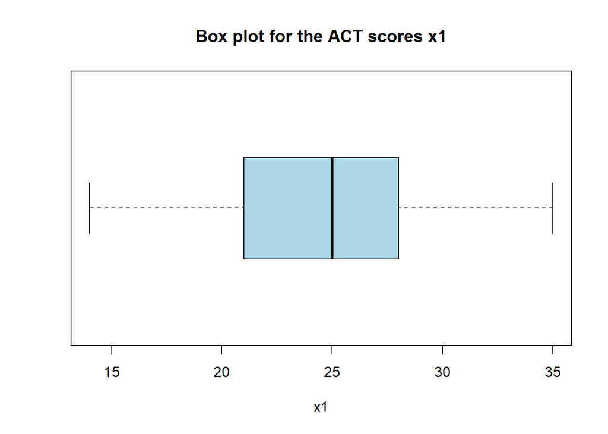

```r
boxplot(X,
        main = "Box plot for the ACT scores x1",
        xlab = "x1",
        col = "lightblue",
        horizontal = TRUE
        )
```

Based on the median of the data is observed to be at 25. The box plot observed is not perfectly symmetric and it is seem to skewed slightly to the left. This may imply that the model may depart from normality.

r.Plot the residual $e_{i}$ against the fitted values $\hat{Y}_{i}$. What departures from regression model (2.1) can be studied from this plot? What are your findings?

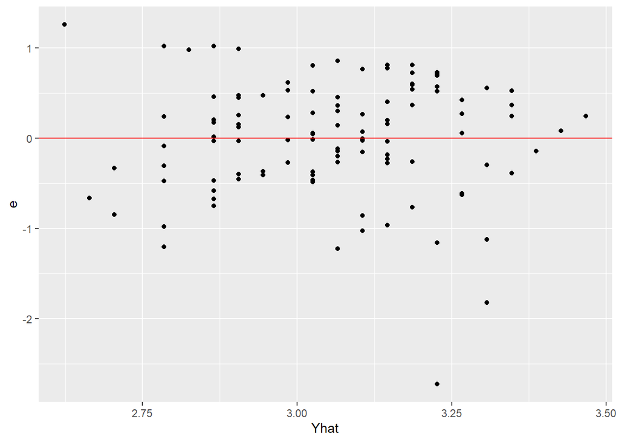

```r
plotdata = data.frame(X, Y, Yhat, e)

residual_plot = ggplot(plotdata, aes(x = Yhat, y = e)) +
  geom_point() +
  geom_hline(yintercept = 0, color = "red")

residual_plot
```

The residuals are observed to be random and appears to fall within a horizontal band centered around 0 (somewhere between 1.5 and -1.5) implying it is linear with constant variance. Also the residuals displaying no systematic tendencies to be positive and negative, but with a presences of one or two outliers, thus suggesting linear regression model is somewhat appropriate.

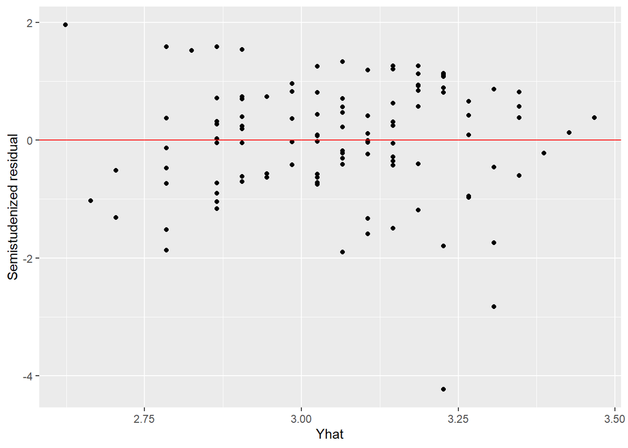

```r
semi_e = e / sqrt(MSE)

semistudenized_residual_plot = ggplot(plotdata, aes(x = Yhat, y = semi_e)) + geom_point() +
  geom_hline(yintercept = 0, color = "red") + xlab("Yhat") + ylab("Semistudenized residual")

semistudenized_residual_plot
```

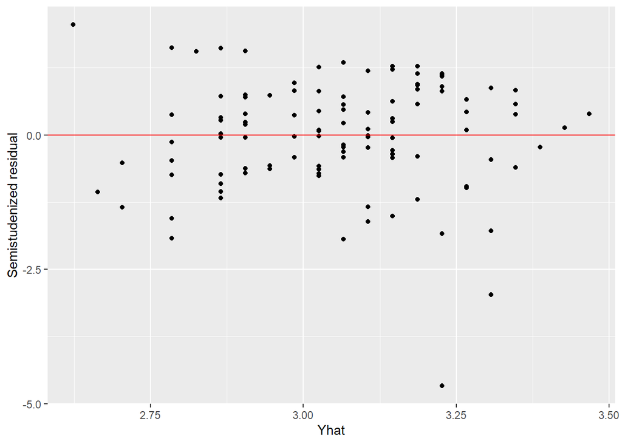

```r
semistudenized_residual_plot2 = ggplot(plotdata, aes(x = Yhat, y = studres(my_lr_model)))+
  geom_point() +
  geom_hline(yintercept = 0, color = "red") + xlab("Yhat") + ylab("Semistudenized residual")

semistudenized_residual_plot2
```

s.Prepare a normal probability plot of the residuals. What do you conclude?

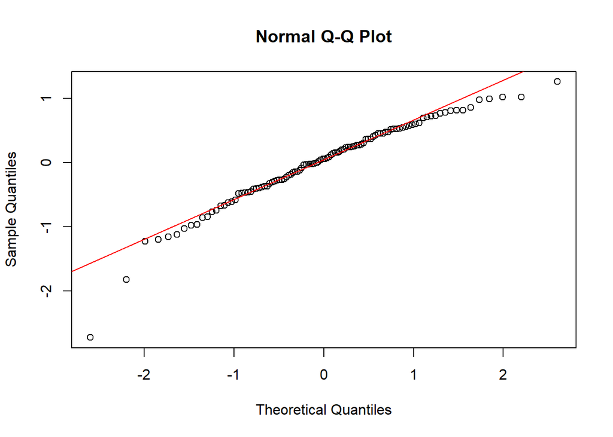

```r
qqnorm(resid(my_lr_model))

qqline(resid(my_lr_model), col = "red")
```

The normal probability plot of the residuals shows that most of the distribution is approximately linear, suggesting the condition that the error terms of normally distirbuted, with a few points departed from linearity. Thus simple linear regression model appears to be somewhat appropriate but not with the best fit.

t.Information is also given the table for each student on two variables not included in the model, namely intelligence test score ($X_{2}$) and high school class rank percentile ($X_{3}$). (Note that larger class rank percentiles indicate higher standing in the class, e.g., 1% is near the bottom of the class and 99% is near the top of the class.) Plot the residuals against $X_{2}$ and $X_{3}$ on separate graphs to ascertain whether the model can be improved by including either of these variables. What do you conclude?

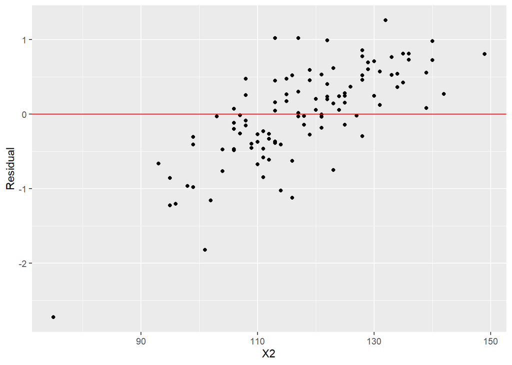

```r
datax2 = random_sample_data[ ,c("Yi","Xi2")] # random sample data x2
my_lr_model_x2 = lm(Yi ~ Xi2, datax2) # linear regression function
x2_residual = resid(my_lr_model_x2)   # obtain residual function

residual_plot_x2 = ggplot(datax2, aes(x = Xi2, y = e)) +
  geom_point() + geom_hline(yintercept = 0, color = "red") + xlab("X2") + ylab("Residual")

residual_plot_x2
```

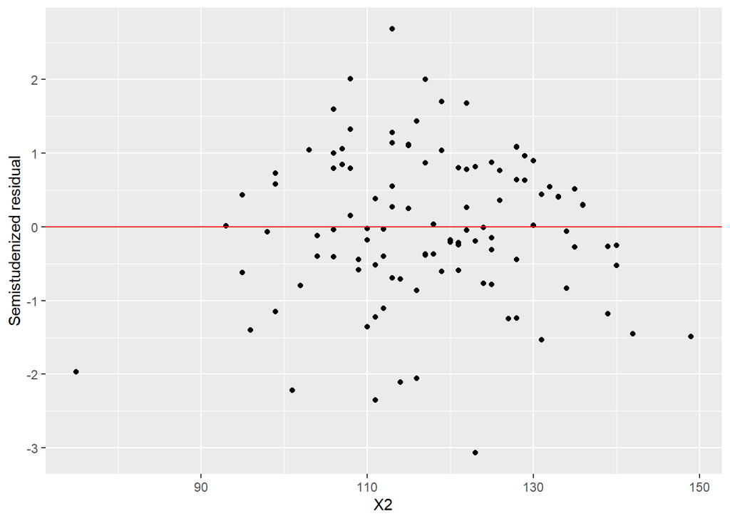

```r
semistudenized_residual_x2 = ggplot(datax2, aes(x = Xi2, y = studres(my_lr_model_x2))) +
  geom_point() +
  geom_hline(yintercept = 0, color = "red") + xlab("X2") + ylab("Semistudenized residual")

semistudenized_residual_x2
```

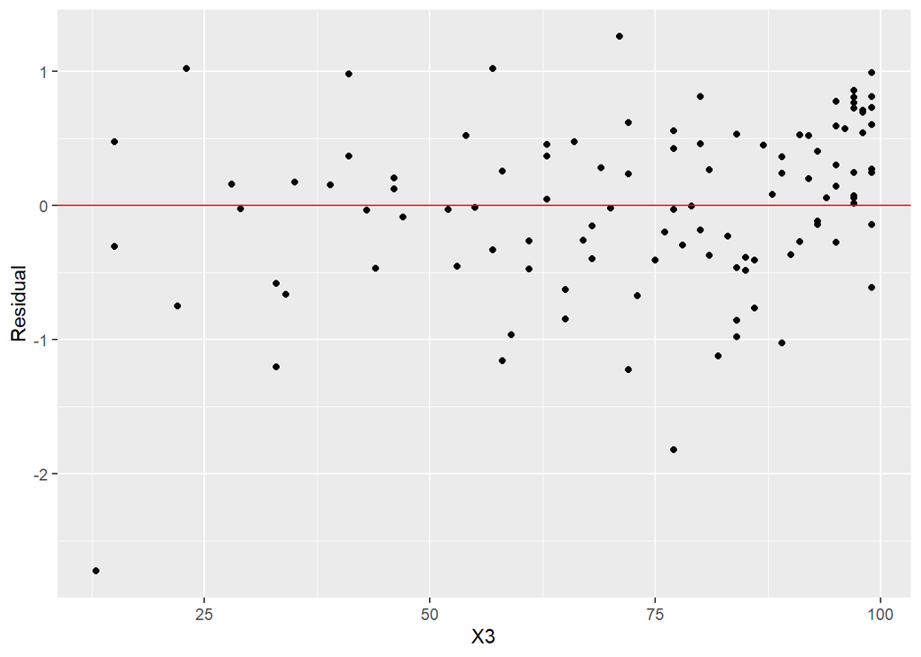

```r
datax3 = random_sample_data[ ,c("Yi","Xi3")] # random sample data x3
my_lr_model_x3 = lm(Yi ~ Xi3, datax3) # linear regression function

x3_residual = resid(my_lr_model_x3)   # obtain residual function

residual_plot_x3 = ggplot(datax3, aes(x = Xi3, y = e)) +
  geom_point() + geom_hline(yintercept = 0, color = "red") + xlab("X3") + ylab("Residual")

residual_plot_x3
```

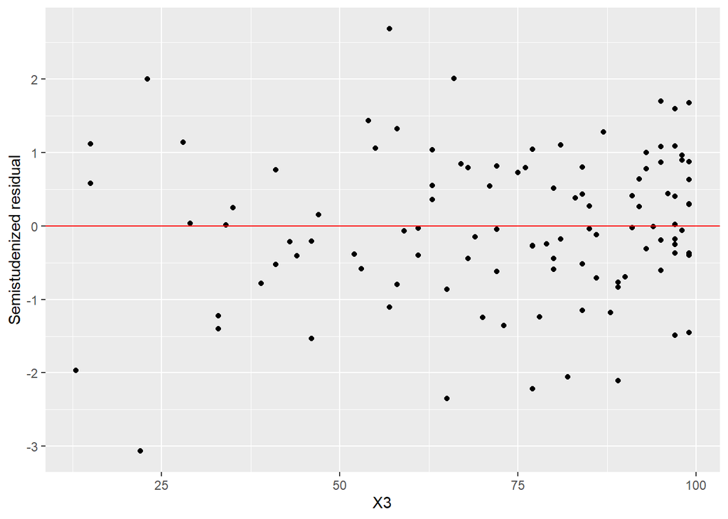

```r
semistudenized_residual_x3 = ggplot(datax3, aes(x = Xi3, y = studres(my_lr_model_x2))) +
  geom_point() +
  geom_hline(yintercept = 0, color = "red") + xlab("X3") + ylab("Semistudenized residual")

semistudenized_residual_x3
```

The plot of residuals against $X_{2}$ appears to have a positive slope departs from the baseline 0, for lower X2 seems to have more negative residuals and for upperX2 seems to have more postive residuals, this suggests that the residuals are to random, thus implying nonlinearity, therefore simple linear regression function is not appropriate.

The plot of residuals against $X_{3}$ shows that the residuals are distributed randomly around the baseline 0 and it is also observe to have constant variance (somewhat between 3 and -3), thus suggesting simple linear regression model is appropriate.